# Local Authorities in the UK with high rates or numbers of COVID-19 cases

Analysis by Colin Angus with thanks to Francisco Rowe for helping me work GitHub Pages

04/11/2020

```r
casetable
```

Local Authorities in the UK with the highest number of new COVID cases

Based on 7-day rolling average of Pillar 1 and 2 tests combined

Local Authority

Data up to<sup>1</sup>

Country

Current cases per day

Change in daily cases in the last 7 days

Last month

Total

Rate per 100,000

Total

Rate per 100,000

Leeds

30 October

England

474.9

60.2

6.6 ▲

0.8

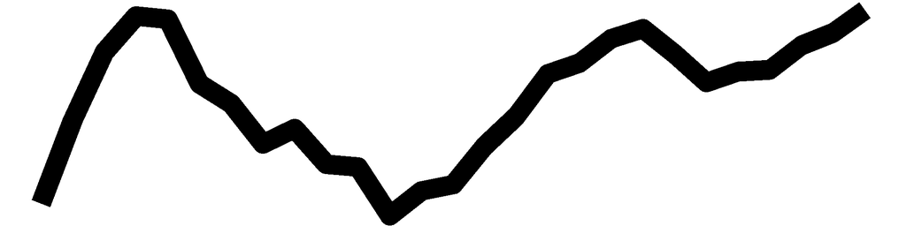

Birmingham

30 October

England

467.3

40.9

15.0 ▲

1.3

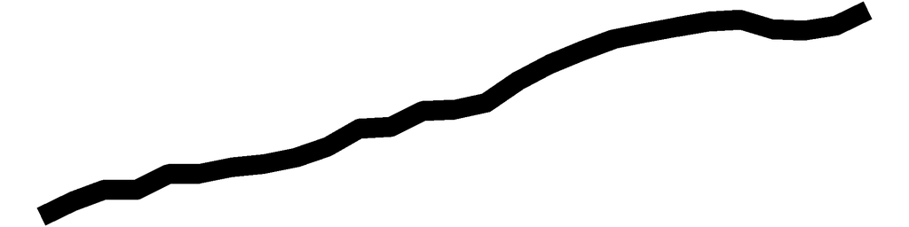

Bradford

30 October

England

421.6

78.5

41.7 ▲

7.8

Manchester

30 October

England

359.7

65.7

−35.6 ▼

−6.5

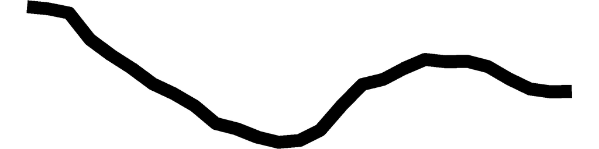

Kirklees

30 October

England

323.4

73.7

63.0 ▲

14.4

Sheffield

30 October

England

312.6

53.7

−60.0 ▼

−10.3

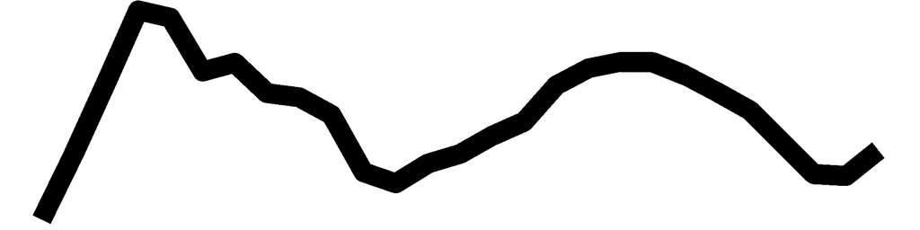

Wigan

30 October

England

298.7

91.6

−24.9 ▼

−7.6

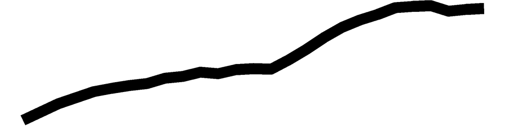

Glasgow City

30 October

Scotland

259.3

41.4

−42.7 ▼

−6.8

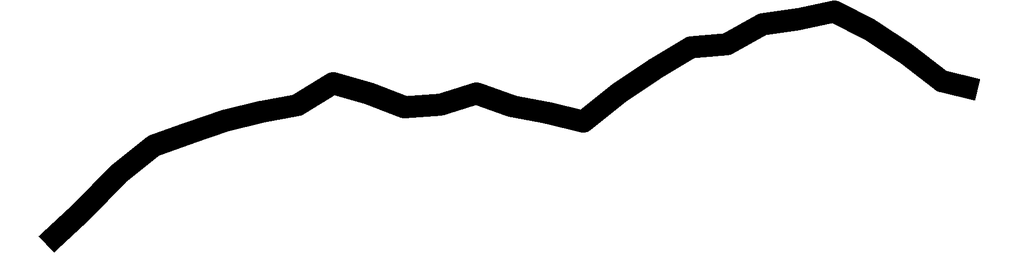

Oldham

30 October

England

257.4

109.3

18.9 ▲

8.0

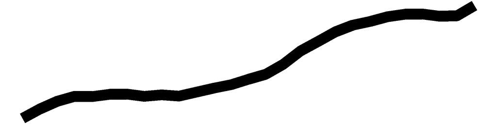

Bristol, City of

30 October

England

244.7

52.8

−11.3 ▼

−2.4

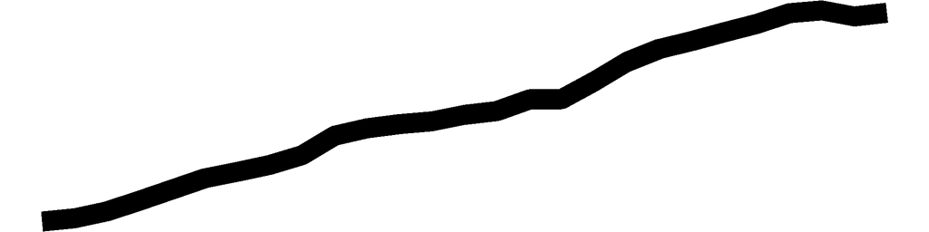

Data from PHE, PHW, DoHNI and ScotGov | Analysis by @VictimOfMaths

<sup>*1*</sup> Data from the most recent 4 days available is excluded as this is often very incomplete

```r
ratetable
```

Local Authorities in the UK with the highest rate of new COVID cases

Based on 7-day rolling average of Pillar 1 and 2 tests combined

Local Authority

Data up to<sup>1</sup>

Country

Current cases per day

Change in daily cases in the last 7 days

Last month

Rate per 100,000

Total

Rate per 100,000

Total

Oldham

30 October

England

109.3

257.4

8.0 ▲

18.9

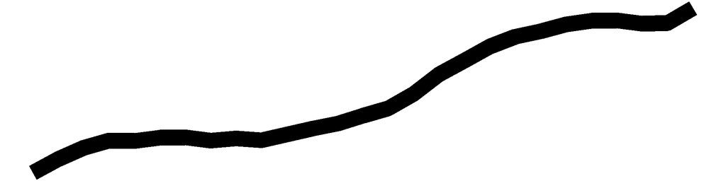

Blackburn with Darwen

30 October

England

99.4

148.0

−11.2 ▼

−16.7

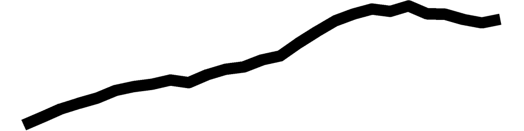

Wigan

30 October

England

91.6

298.7

−7.6 ▼

−24.9

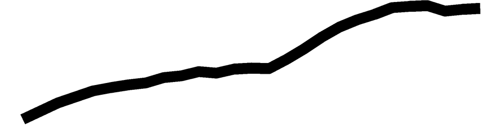

Salford

30 October

England

87.8

223.3

−1.2 ▼

−3.0

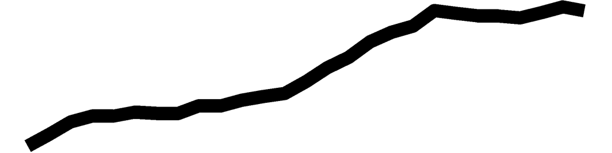

Merthyr Tydfil

30 October

Wales

87.4

52.6

3.3 ▲

2.0

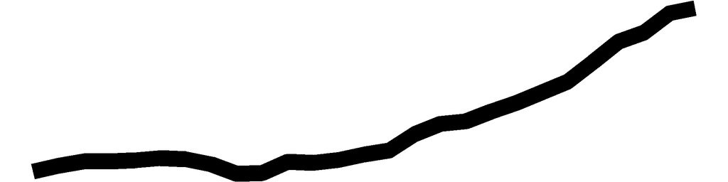

Rochdale

30 October

England

81.2

178.6

−4.7 ▼

−10.3

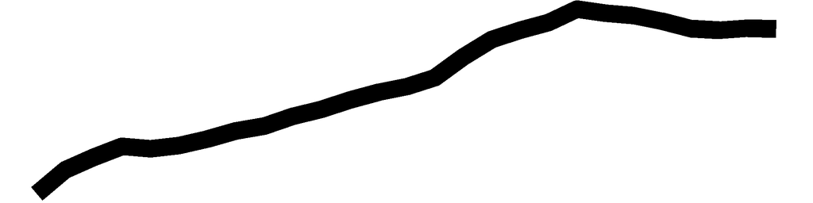

Bury

30 October

England

79.8

151.7

0.5 ▲

1.0

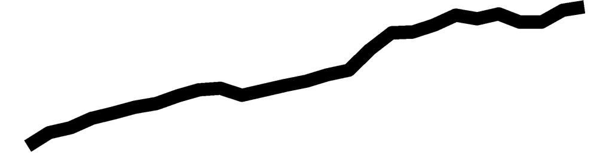

Bradford

30 October

England

78.5

421.6

7.8 ▲

41.7

Bolton

30 October

England

76.7

218.9

−5.4 ▼

−15.3

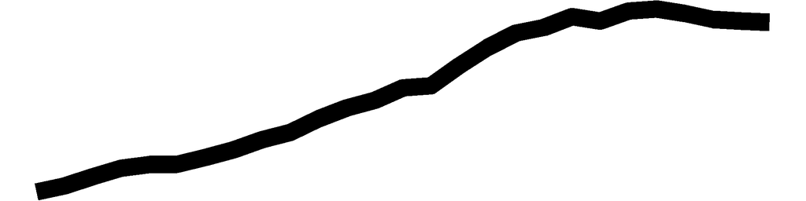

Barnsley

30 October

England

74.1

181.7

1.5 ▲

3.7

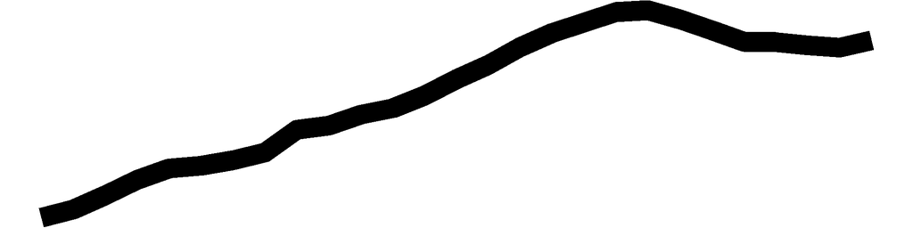

Data from PHE, PHW, DoHNI and ScotGov | Analysis by @VictimOfMaths

<sup>*1*</sup> Data from the most recent 4 days available is excluded as this is often very incomplete

```r
casechangetable
```

Local Authorities in the UK with biggest rise in new COVID-19 case numbers in the last week

Based on 7-day rolling average of Pillar 1 and 2 tests combined

Local Authority

Data up to<sup>1</sup>

Country

Change in daily cases in the last 7 days

Current cases per day

Last month

Total

Rate per 100,000

Total

Rate per 100,000

Kingston upon Hull, City of

30 October

England

68.3 ▲

26.2

186.7

71.6

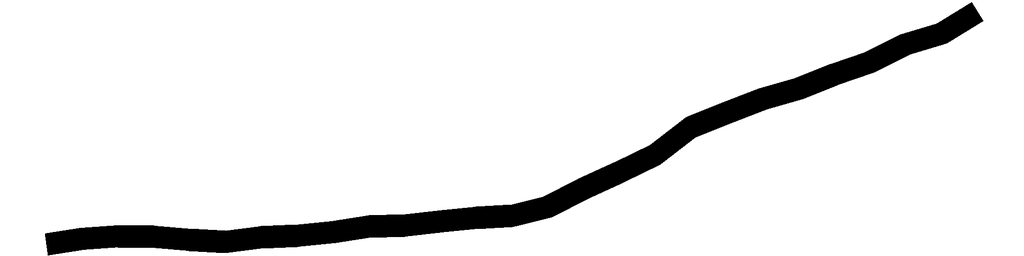

Kirklees

30 October

England

63.0 ▲

14.4

323.4

73.7

Dudley

30 October

England

46.6 ▲

14.5

167.4

52.2

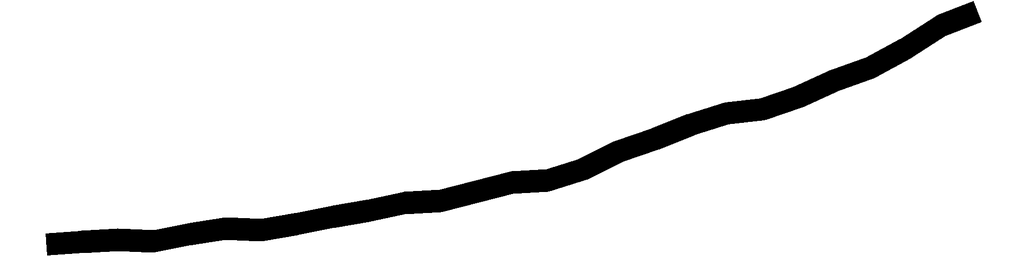

Bradford

30 October

England

41.7 ▲

7.8

421.6

78.5

Shropshire

30 October

England

25.4 ▲

7.9

88.0

27.5

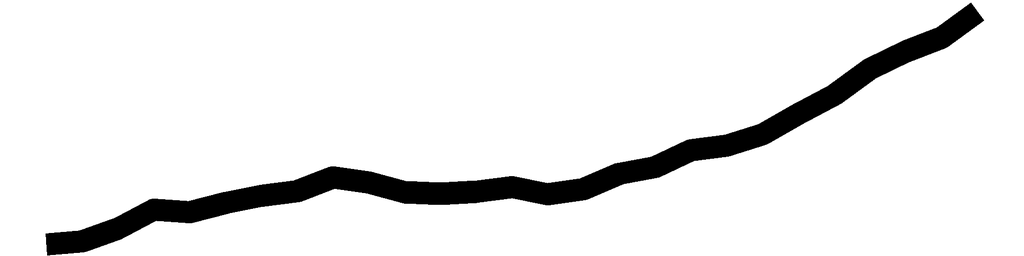

Newcastle-under-Lyme

30 October

England

24.4 ▲

18.9

79.1

61.1

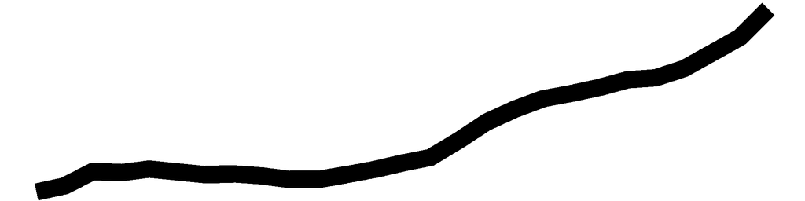

East Riding of Yorkshire

30 October

England

21.9 ▲

6.4

155.9

45.9

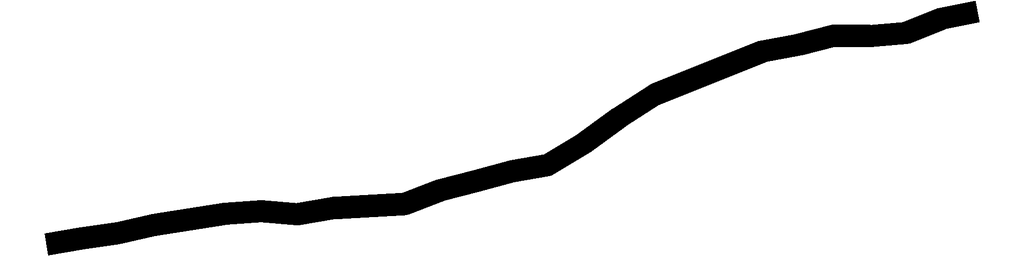

Stafford

30 October

England

21.1 ▲

15.6

68.9

50.7

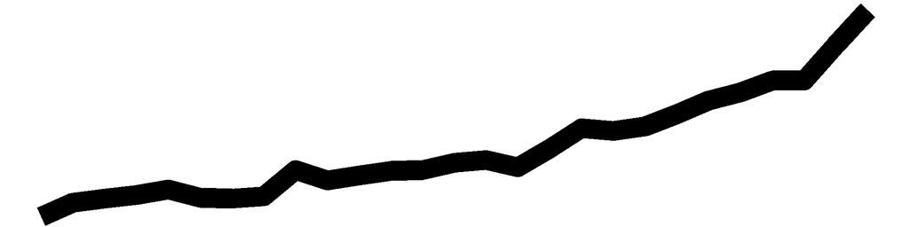

Stoke-on-Trent

30 October

England

20.6 ▲

8.0

136.3

53.3

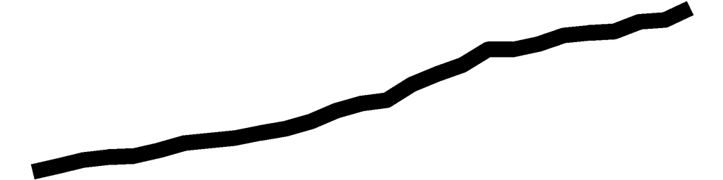

Medway

30 October

England

19.6 ▲

7.0

57.4

20.7

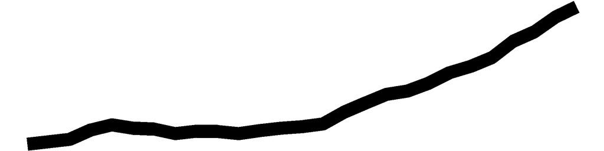

Data from PHE, PHW, DoHNI and ScotGov | Analysis by @VictimOfMaths

<sup>*1*</sup> Data from the most recent 4 days available is excluded as this is often very incomplete

```r
ratechangetable
```

Local Authorities in the UK with biggest rise in new COVID-19 case rates in the last week

Based on 7-day rolling average of Pillar 1 and 2 tests combined

Local Authority

Data up to<sup>1</sup>

Country

Change in daily cases in the last 7 days

Current cases per day

Last month

Rate per 100,000

Total

Rate per 100,000

Total

Kingston upon Hull, City of

30 October

England

26.2 ▲

68.3

71.6

186.7

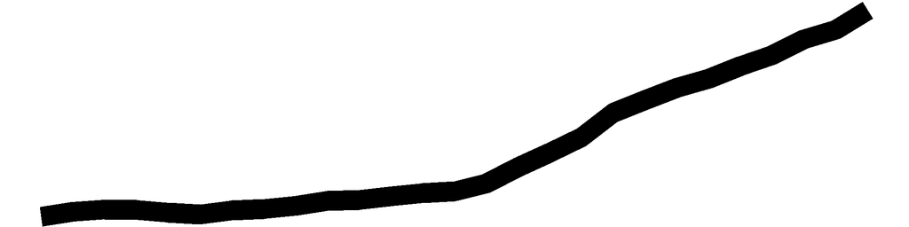

Newcastle-under-Lyme

30 October

England

18.9 ▲

24.4

61.1

79.1

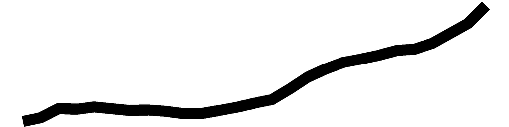

Stafford

30 October

England

15.6 ▲

21.1

50.7

68.9

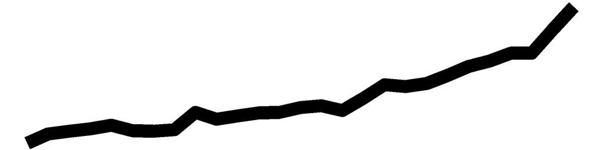

Dudley

30 October

England

14.5 ▲

46.6

52.2

167.4

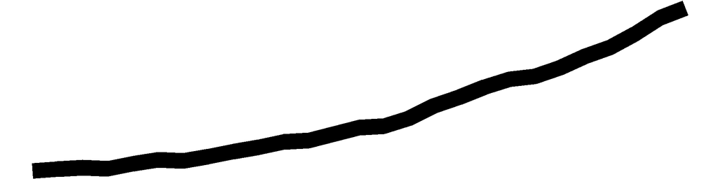

Kirklees

30 October

England

14.4 ▲

63.0

73.7

323.4

Bassetlaw

30 October

England

13.0 ▲

15.1

59.7

69.7

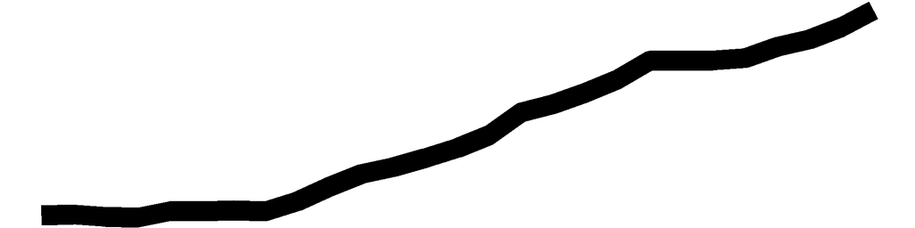

Wyre Forest

30 October

England

12.0 ▲

12.1

30.4

30.7

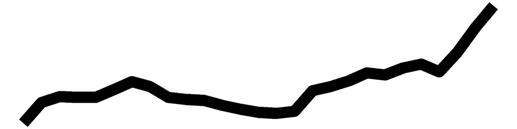

Amber Valley

30 October

England

10.9 ▲

13.9

48.0

60.9

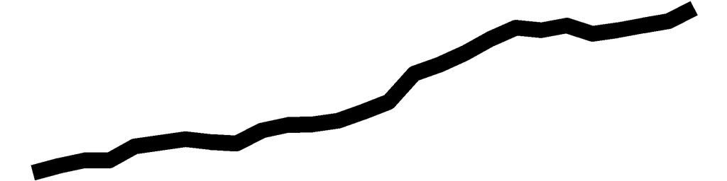

Bolsover

30 October

England

10.8 ▲

8.6

59.6

47.4

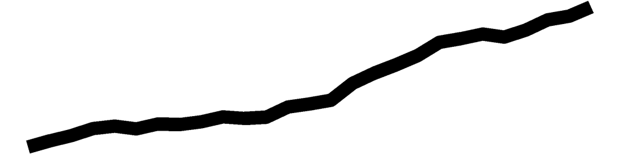

North East Lincolnshire

30 October

England

10.7 ▲

17.1

65.2

104.1

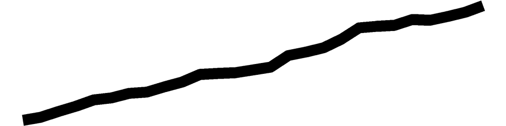

Data from PHE, PHW, DoHNI and ScotGov | Analysis by @VictimOfMaths

<sup>*1*</sup> Data from the most recent 4 days available is excluded as this is often very incomplete